# Panda Bear Spotify Analysis

Author

Marek Chuman

# Panda Bear Data Breakdown

## Artist Background

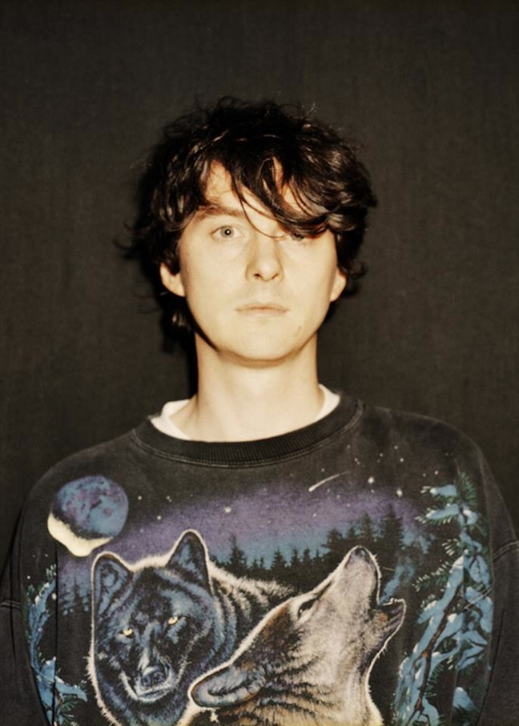

- Solo Project of Noah Lennox from Animal Collective
- Born in Baltimore, Maryland. Currently living in Lisbon
- Musical style combines psychadelic pop, sampling and vocal layering
- Focus on repetition

### Albums Released

- Panda Bear (1999)
- Young Prayer (2004)
- Person Pitch (2007)
- Tomboy (2011)
- Panda Bear Meets the Grim Reaper (2015)
- Buoys (2019)
- Reset (2022)
- Sinister Grift (2025)

## Personal Favorites

#### Fav Album

[figure not shown]

*Sinister Grift (2025)*

#### Fav Song

[Praise - Panda Bear](https://www.youtube.com/watch?v=MhNGN4SnRZM&list=PLGcVcCzvzVodur0wfnrmW6eFMxft1hNDk&index=1)

[video not shown]

## Data Analysis

#### Data Collection

I have collected the data using the Spotify Music Analysis Server. Doing that I created a dataset from scratch. I only included album songs

#### Data Importing

To import the data I have used the following function, along with getting my packages in order.

```r
library(ggplot2) #these are the packages I used for my analysis
library(dplyr)
library(knitr)

PBData <- read.csv("pb.csv.csv") # stored all of my data under this name
```

You can take a look at some of the data over here

```r
PBData |> dplyr::slice_sample(n=5) |> knitr::kable(digits = 2)
```

| Song | Acousticness | Danceability | Energy | Instrumentalness | Liveness | Loudness | Speechiness | Tempo | Valence | album_name |
| --- | --- | --- | --- | --- | --- | --- | --- | --- | --- | --- |
| Master | 0.27 | 0.59 | 0.51 | 0.00 | 0.08 | -8.14 | 0.08 | 80.48 | 0.50 | Buoys |
| Ends Meet | 0.05 | 0.71 | 0.68 | 0.00 | 0.23 | -5.30 | 0.04 | 114.03 | 0.85 | Sinister Grift |
| Untitled 5 | 0.73 | 0.80 | 0.84 | 0.25 | 0.07 | -9.48 | 0.06 | 138.95 | 0.93 | Young Prayer |
| Comfy In Nautica | 0.68 | 0.45 | 0.86 | 0.00 | 0.36 | -14.69 | 0.16 | 119.92 | 0.04 | Person Pitch |
| Home Free | 0.07 | 0.72 | 0.30 | 0.06 | 0.07 | -10.27 | 0.04 | 105.82 | 0.23 | Buoys |

#### Data Preparation

I really didn’t need to mess with the data in any way, as I have all collected it by hand.

#### Valence/Energy Analysis by Album

I was curious to see in which sector of the graph would Panda Bear songs prevalently lie in(Angry/Joyful/Peaceful/Sad)

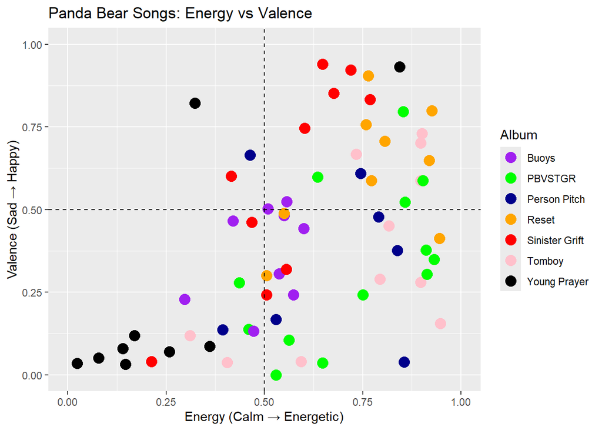

```r
library(ggplot2)
ggplot(PBData, aes(x = Energy,
                   y = Valence,
                   color = album_name)) +

  geom_point(size = 4, alpha = 1) +

  geom_vline(xintercept = 0.5,
             linetype = "dashed",
             color = "black") +

  geom_hline(yintercept = 0.5,
             linetype = "dashed",
             color = "black") +

  scale_color_manual(values = c(  #colors were chosen on visibility
    "Reset" = "orange",
    "Tomboy" = "pink",
    "Person Pitch" = "darkblue",
    "Buoys" = "purple",
    "PBVSTGR" = "green",
    "Sinister Grift" = "red",
    "Young Prayer" = "black"
  )) +

  scale_x_continuous(limits = c(0, 1)) +
  scale_y_continuous(limits = c(0, 1)) +

  labs(title = "Panda Bear Songs: Energy vs Valence",
       x = "Energy (Calm → Energetic)",
       y = "Valence (Sad → Happy)",
       color = "Album")
```

While seeing all the songs at once on a scatter chart was cool, I wanted to break it down further for Energy and Valence using Histograms and Boxplots

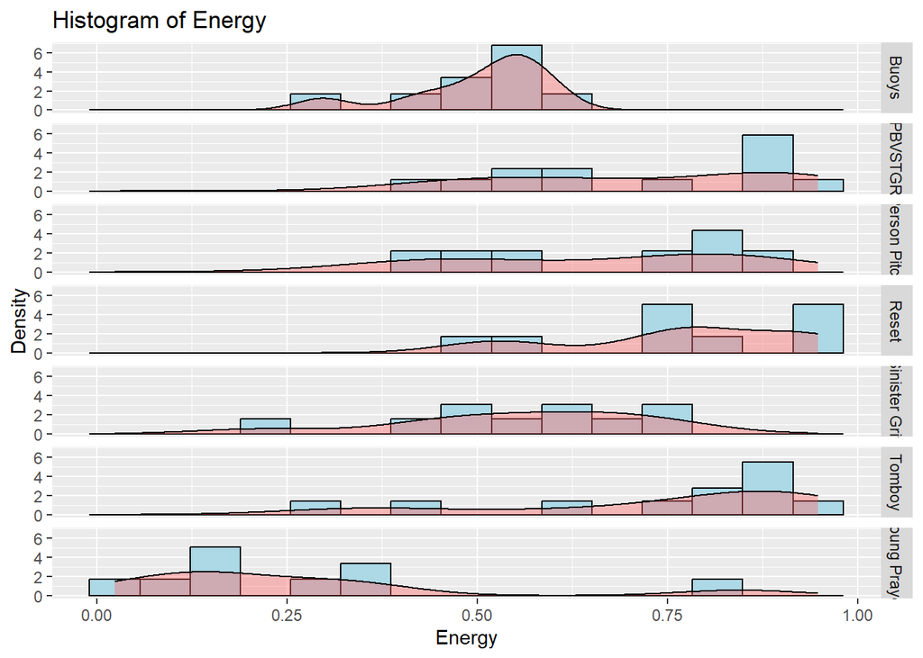

```r
ggplot(PBData, aes(x = Energy)) +
  geom_histogram(aes(y = ..density..),
                 fill = "lightblue",
                 color = "black",
                 bins = 15) +
  geom_density(fill = "#FF6666",
               alpha = 0.4) +
  facet_grid(album_name ~ .) +
  labs(title = "Histogram of Energy",
       x = "Energy",
       y = "Density")
```

It seems that Panda Bear’s early work is more mellow

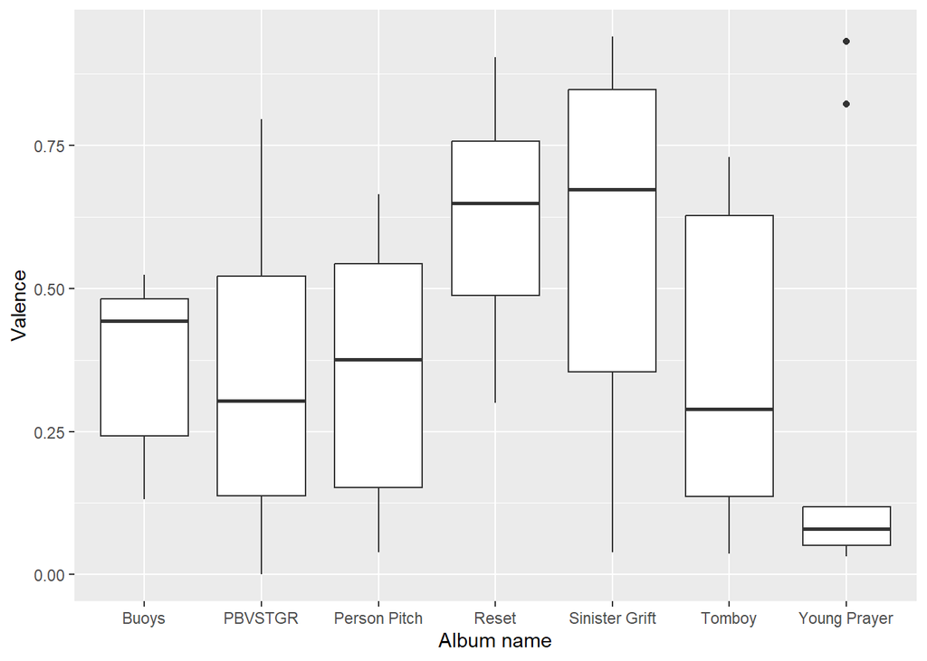

```r
library(ggplot2)

PBData$album_name <- as.factor(PBData$album_name)

ggplot(PBData, aes(x = album_name, y = Valence)) +
  geom_boxplot() +
  labs(x = "Album name",
       y = "Valence")
```

## Most Positive/Negative Tracks

I was curious to find out what would Panda Bears five most positive and negative tracks be. For that I used the following code(positive first, negative after)

```r
PBData |>
  slice_max(Valence, n = 5) |>
  select(Song, album_name, Valence) |>
  kable(digits = 2)
```

| Song | album_name | Valence |
| --- | --- | --- |
| Just as Well | Sinister Grift | 0.94 |
| Untitled 5 | Young Prayer | 0.93 |
| Ferry Lady | Sinister Grift | 0.92 |
| Gettin to the Point | Reset | 0.90 |
| Ends Meet | Sinister Grift | 0.85 |

```r
PBData |>
  slice_min(Valence, n = 5) |>
  select(Song, album_name, Valence) |>
  kable(digits = 2)
```

| Song | album_name | Valence |
| --- | --- | --- |
| Shadow Of The Colossus | PBVSTGR | 0.00 |
| Untitled 4 | Young Prayer | 0.03 |
| Untitled 7 | Young Prayer | 0.03 |
| Davy Jones’ Locker | PBVSTGR | 0.04 |
| Drone | Tomboy | 0.04 |

The Spotify Music Analysis Server does not know that those are interludes. Let’s fix that

```r
library(dplyr)
library(knitr)

PBData |>
  arrange(Valence) |>
  slice(5:9) |>              # skip first 4 interludes, take next 5 tracks
  select(Song, album_name, Valence) |>
  kable(digits = 2)
```

| Song | album_name | Valence |
| --- | --- | --- |
| Drone | Tomboy | 0.04 |
| Comfy In Nautica | Person Pitch | 0.04 |
| Elegy for Noah Lou | Sinister Grift | 0.04 |
| Benfica | Tomboy | 0.04 |
| Untitled 8 | Young Prayer | 0.05 |

Now let’s look at the most/least danceable songs to see if there’s any overlap

```r
PBData |>
  slice_max(Danceability, n = 5) |>
  select(Song, album_name, Danceability) |>
  kable(digits = 2)
```

| Song | album_name | Danceability |
| --- | --- | --- |
| Untitled 5 | Young Prayer | 0.80 |
| Go On | Reset | 0.75 |
| Home Free | Buoys | 0.72 |
| Ends Meet | Sinister Grift | 0.71 |
| Selfish Gene | PBVSTGR | 0.71 |

```r
PBData |>
  slice_min(Danceability, n = 5) |>
  select(Song, album_name, Danceability) |>
  kable(digits = 2)
```

| Song | album_name | Danceability |
| --- | --- | --- |
| Drone | Tomboy | 0.09 |
| Scheherazade | Tomboy | 0.09 |
| Benfica | Tomboy | 0.12 |
| Lonely Wanderer | PBVSTGR | 0.14 |
| Davy Jones’ Locker | PBVSTGR | 0.16 |

[video not shown]